# RaceReport

## Fantasy League Scores

Scores for drivers/constructors in the current year's fantasy league, along with manager/team points, values, and statistics. Note: driver and constructor values are taken as the cost to enter the current race and are updated the week before the race.

## Lineup Scores

Race winner Oscar Piastri takes the top spot this week, unchallenged out front with 45 points, a significant advantage over his nearest rival. Rookie sensation Isack Hadjar takes second place with 33 points, ahead of Max Verstappen in third with 29. Ollie Bearman and Alex Albon come home in fourth place with 27 points each, and Lance Stroll rounds out the top five, despite crashing twice, with 21 points. There's some unfamiliar names at the bottom this week, with Lewis Hamilton taking the honours with -16 points after his DNF. His teammate Leclerc is next with -13 points, followed by previous championship leader Lando Norris with -5 points. Bortoleto, Gasly, and Lawson are next, all coming home with 0 points, followed by Antonelli and Sainz with 1 point each.

McLaren continue to dominate this week with 52 points ahead of Red Bull with 47. Haas take a solid third place with 43 points and it's fairly tight down to Williams in sixth. Ferrari score -4 points this week at the bottom of the table, behind Alpine and Kick Sauber with 14 points each. Mercedes round out the bottom three with 30 points.

McLaren continue their stranglehold over the season at the top with 1267 points ahead of Ferrari and Mercedes with 709 and 635 points each. Alpine are still yet to hit triple figures with 81 points at the bottom of the table, but then the fight gets really spicy. Kick Sauber drop down to second from last this week with 242 behind Williams with 246 and Racing Bulls with 249 points.

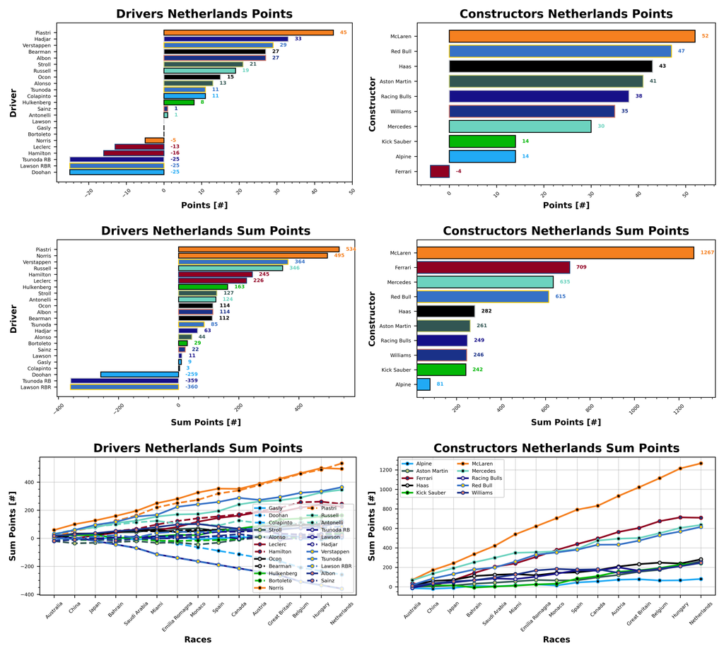

Lando Norris remains your most expensive option this week, setting you back a cool 31.4. Then we have Max Verstappen at 282, Oscar Piastri at 26.4, Charles Leclerc at 23.9, and Lewis Hamilton setting you back 23.6. A quartet of drivers fell down to the season minimum this week, those were Bortoleto, Colapinto, Doohan, and Lawson who all cost 4.5. Then it's first-time podium sitter Isack Hadjar at 5.1, Pierre Gasly at 5.4, Carlos Sainz at 5.9, and Alonso/Bearman at 7.5.

All values are in Million Dollars.

Russell and Piastri maintain their 100% record, I wonder if they can go all season this way. Then it's Verstappen and Ocon who have dropped 1 race this season, followed by Stroll, Norris, Hulkenberg, and Hamilton as your third most positive scorers. Colapinto remains at the bottom, scoring positively in only 1/3 of the races this season, followed by teammate Gasly and Lawson just above 50%. Tsunoda and Bortoleto are next at 60%, followed by Sainz and Antonelli, who scored positively at 2/3 of the races this year. Hadjar and Alonso round out the bottom five, just under 3/4 of the races scored with positive points.

Red Bull, Mercedes and McLaren maintain their 100% record this season, with Alpine down at the bottom, scoring positively at only 2/3 of the races this season. Your outliers are Racing Bulls at 73% and Aston Martin at 93%. The other teams are all tied at 86%.

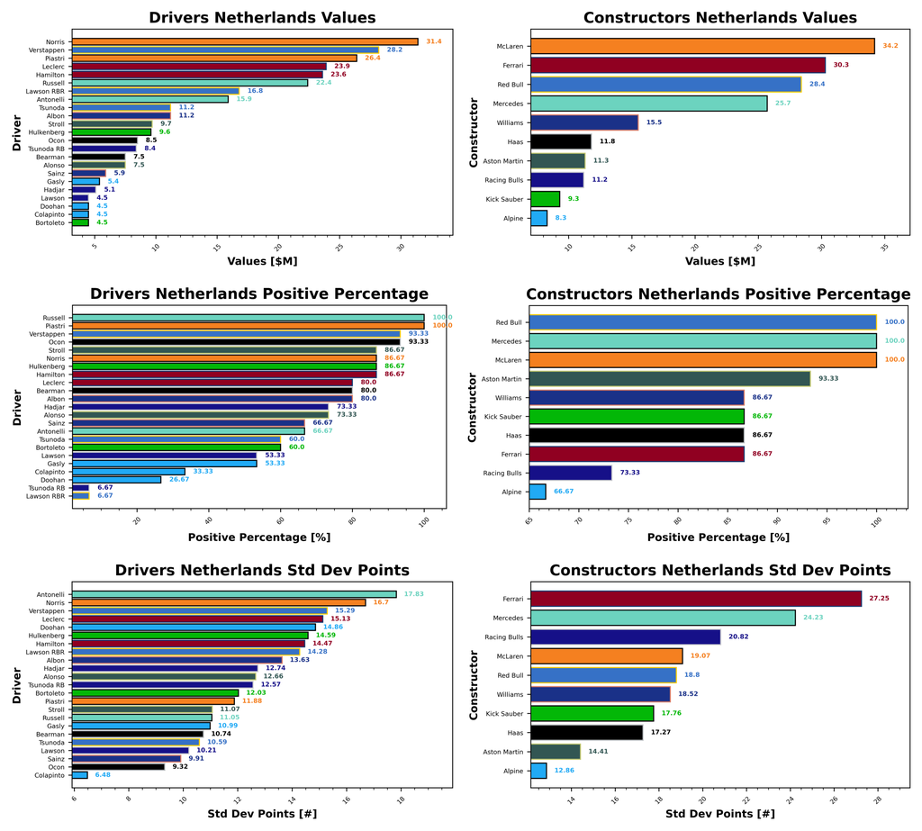

Colapinto remains your most reliable driver of the season, with a standard deviation from his average score of 6.48 points. Ocon, Sainz, Lawson, and Tsunoda are the remaining consistent drivers of the top five. Your least consistent driver of the season is rookie Kimi Antonelli, with a standard deviation of 17.83 points. Alpine are your most consistent team of the season with a standard deviation of 12.86 points, they're followed by Aston Martin and Haas. Your least consistent team is Ferrari with a standard deviation of 27.25 points.

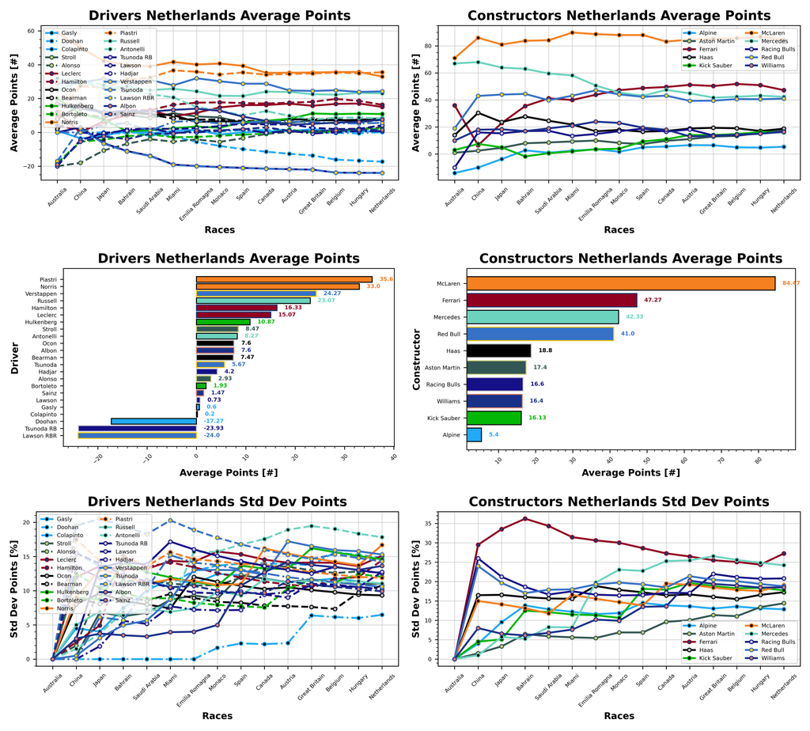

Haas dethrone Aston Martin this week with a points per value of 3.64 ppm, the Silverstone team come home in second with 3.63 ppm, and Racing Bulls round out the top three with 3.39 ppm. Ferrari were your worst team of the week with -0.13 ppm, behind Mercedes with 1.17 ppm, and Kick Sauber with 1.51 ppm.

ppm = points per million Dollars.

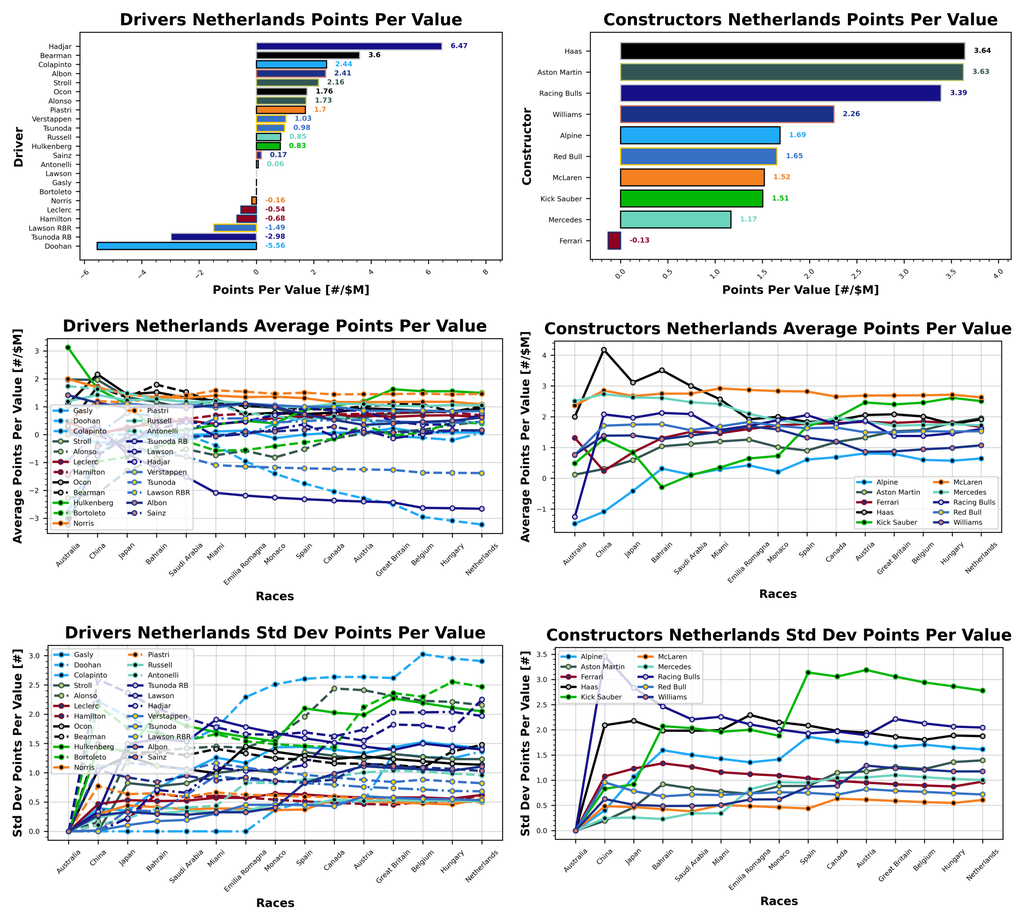

### Manager Scores

Alfie returns to the top step this week with I Call Patrick Subaru bringing home 268 points ahead of Stuart and Murder On Zidane's Floor with 265. Phil and BMW Should Be Here are in third place with 258 ahead of Josh and Expensify APX GP with 248. Sam and Grand Prix Princesses F1 round out the top five with 243 points.

Golf League Leader Stuart and Taylormade To Lose extend their advantage with a score of 22 this week, ahead of Valerie and Perez For World Champion with 31 points. Jake and I Am Stupid Rookie are in third with 45 points, with Valerie and What Arrrgh Ya Doohan next with 50 points. Alfie and Cucumberpotatolamborghini round out the bottom five with 51 points.

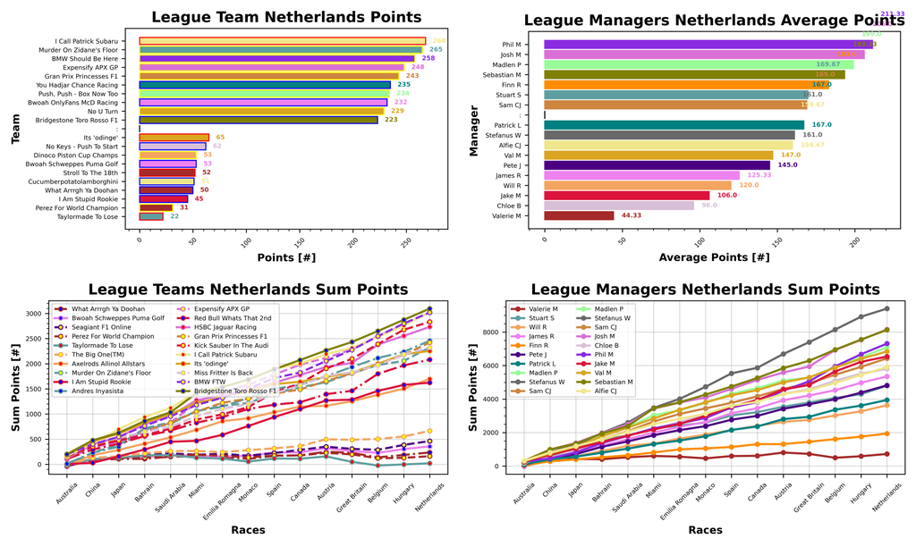

Stefanus and Syahrul hold on to the top step with 3308 points, but the empire is crumbling. Sebastian and Bridgestone Toro Rosso F1 work their way back up to second place with 3097 points ahead of Patrick and You Hadjar Chance Racing in third with 3071 points. Stefanus rounds out the top five with Gelael and Haryanto with 3055 and 3038 points each.

Stuart and Taylormade To Lose seem to have the Golf League sealed up at the moment with 20 points to their name. Valerie occupies the next three positions with Perez For World Champion, What Arrrgh Ya Doohan, and Stroll to the 18th with 161, 236, and 326 points. James and Bwoah Schweppes Puma Golf round out the bottom five with 356.

Biggest winner of the week this week is Sam and Grand Prix Princesses F1 who jump 4 places in the standings. Our biggest loser this week is Val and Its Odinge, who drop 5 places down the grid.

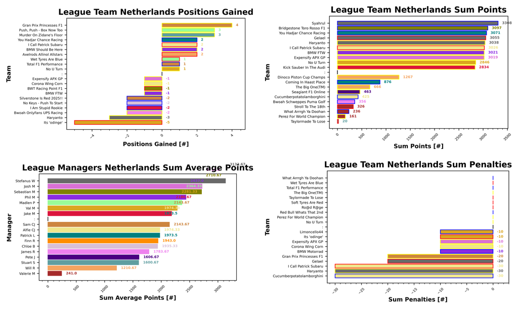

Very few changes to teams this week, with many of you sticking to your guns after the summer break. Hadjar stays as your most popular with 27 selections, followed by Piastri with 22, Hulkenberg/Alonso with 21, Lawson/Bortoleto with 15, and Sainz with 13. Hamilton, Tsunoda, and Verstappen were your least chosen with only 2 selections each. Then we have Antonelli with 5, Leclerc/Gasly with 6, Norris/Stroll with 9, and Colapinto/Albon with 10.

McLaren were your most selected team with 19 of you choosing them for your teams. Kick Sauber and Haas have 14 each, with Aston Martin in third with 12. Mercedes were your least chosen team with only 4 selections, followed by Williams with 5, and Red Bull/Alpine with 6 each.

Oscar Piastri stays at the top of the DRS boost count with 21, ahead of Norris/Doohan with 5 and Leclerc with 4. Only one token used this week, and it was a Final Fix.

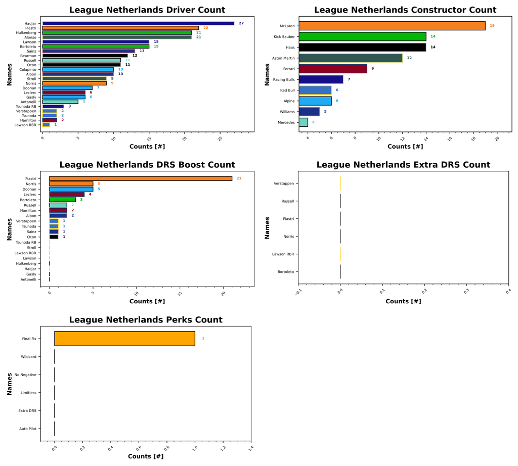

## Prizes

I have now updated the prizes plotting for my code and we should be able to track the season long prizes with ease. So without further adieu, let's take a look at what is currently in play this season.

### Championship

| Prize Name | Prize Value | Terms |
| --- | --- | --- |
|  | (%) |  |
| Champion of the World | 20 | Awarded to the top scorer in the league at the end of the season |
| If You're Not First, You're Last | 10 | Awarded to the second place scorer in the league at the end of the season |
| Alpine Podium | 5 | Awarded to the third place scorer in the league at the end of the season |
| Above Par | 20 | Awarded to the lowest scorer in the league at the end of the season, commonly referred to as the Golf League |

### Achievements

| Prize Name | Prize Value | Terms |
| --- | --- | --- |
|  | (%) |  |
| Cost Cappen | 5 | Highest average points per value at the end of the season |
| Sprint King | 5 | Highest score across the sprint races (China, Miami, Belgium, United States, Brazil, Qatar) |
| Flavio Controls Every Millimeter | 5 | Manager wide substitution count, highest wins |
| The Triple Header | 5 | Highest score across the triple header races (Japan, Bahrain, Saudi Arabia, Emilia Romagna, Monaco, Spain, Las Vegas, Qatar, Abu Dhabi) |
| I Forgot I Was Taking Part | 5 | Highest score in the first part of the season |
| Zak's Master Plan | 5 | Lowest score in the second half of the season |
| Mega Driver | 5 | Highest Extra DRS token score |
| The Continental | 5 | Highest score across all 5 continents, Mexico classed as South America for inclusion only (Australia, Canada, Great Britain, Azerbaijan, Mexico) |

### Spot Prizes

| Prize Name | Prize Value | Terms |
| --- | --- | --- |
|  | (%) |  |
| The Ring | 1 | Highest score at the Austrian Grand Prix |
| Bottas Bowling | 1 | Highest score at the Hungarian Grand Prix |
| Daniel's Broken Hand | 1 | Lowest score at the Netherlands Grand Prix |
| The Tifosi | 1 | Lowest score at the Italian Grand Prix |
| Go For The Gap | 1 | Lowest score at the Singapore Grand Prix |

### Spot Prizes

Netherlands was a spot prize for the lowest score of the week, with those honours going to Stuart and Taylormade To Lose who bring home 22 points.

### Cost Cappen

Stefanus and Syahrul sit at the top of this table, with a points per value of 2.05 ppm. Patrick and You Hadjar Chance Racing are in second with 2.02, ahead of Sebastian and Bridgestone Toro Rosso F1 with 2.01 ppm.

### Flavio Controls Every Millimeter

Stefanus and Gelael lead this one with 36 substitutes, ahead of their other team Haryanto with 34. Josh and Kingfisher Force India F1 are in third with 33, tied with their other team Expensify APX GP.

### Mega Driver

Check back later!

### I Forgot I Was Taking Part

I Forgot I Was Taking Part comes to a close, with Stefanus and Syahrul taking the top step with 3128 points. Haryanto is in second with 2924 points, and Sebastian and Bridgestone Toro Rosso F1 rounds out the podium with 2874 points.

## F1 Predict

Only two people playing this week as Val and Josh fall victim to the mid-season predict link. Phil takes the top step with 108 points ahead of Stuart with 79. All other players scored 0.

So Phil moves into the lead with 875 points, ahead of Stuart in second with 866 points. Val stays in third with 690 ahead of Josh in fourth with 652. Pierce and Matty stay put with 238 and 95 points.

## Next Up

Next up, the temple of speed - Monza. Back-to-back as we approach the end of the season. Monza has a tendency of throwing up some chaos, so be prepared!